# Cwong Assign15

Calvin Wong

5/19/2019

1. Find the equation of the regression line for the given points. Round any final values to the nearest hundredth, if necessary. ( 5.6, 8.8 ), ( 6.3, 12.4 ), ( 7, 14.8 ), ( 7.7, 18.2 ), ( 8.4, 20.8 )

formula = -14.8 + 4.26

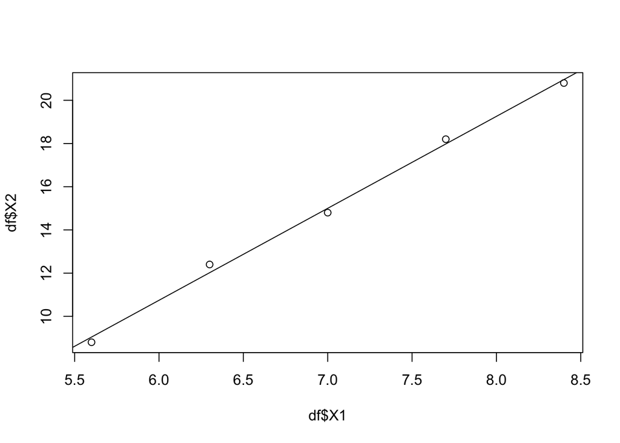

```r
df = data.frame(rbind(c( 5.6, 8.8 ), c( 6.3, 12.4 ), c( 7, 14.8 ), c( 7.7, 18.2 ), c( 8.4, 20.8 )))

model <- lm(df$X2 ~ df$X1, df)

plot(df$X2 ~ df$X1, data=df)
abline(model)
```

```r
summary(model)
```

```
##
## Call:
## lm(formula = df$X2 ~ df$X1, data = df)
##
## Residuals:
##     1     2     3     4     5
## -0.24  0.38 -0.20  0.22 -0.16
##
## Coefficients:
##             Estimate Std. Error t value Pr(>|t|)
## (Intercept) -14.8000     1.0365  -14.28 0.000744 ***
## df$X1         4.2571     0.1466   29.04 8.97e-05 ***
## ---
## Signif. codes:  0 '***' 0.001 '**' 0.01 '*' 0.05 '.' 0.1 ' ' 1
##
## Residual standard error: 0.3246 on 3 degrees of freedom
## Multiple R-squared:  0.9965, Adjusted R-squared:  0.9953
## F-statistic: 843.1 on 1 and 3 DF,  p-value: 8.971e-05
```

2. Find all local maxima, local minima, and saddle points for the function given below. Write your answer(s) in the form ( x, y, z ). Separate multiple points with a comma. f ( x, y ) = 24x - 6xy^2 - 8y^3

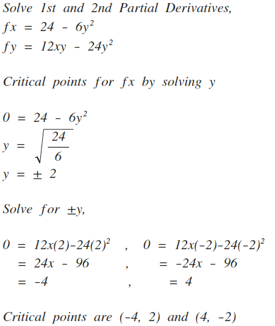

3. A grocery store sells two brands of a product, the “house” brand and a “name” brand. The manager estimates that if she sells the “house” brand for x dollars and the “name” brand for y dollars, she will be able to sell 81 - 21x + 17y units of the “house” brand and 40 + 11x - 23y units of the “name” brand.

Step 1. Find the revenue function R ( x, y ).

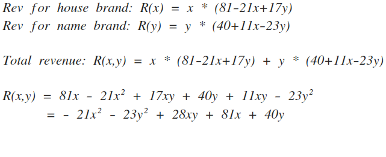

Step 2. What is the revenue if she sells the “house” brand for $2.30 and the “name” brand for $4.10?

```r
x <- 2.3
y <- 4.1

z <- -21*(x^2) - 23*(y^2) + 28*x*y + 81*x +40*y
z
```

```
## [1] 116.62
```

4. A company has a plant in Los Angeles and a plant in Denver. The firm is committed to produce a total of 96 units of a product each week. The total weekly cost is given by C(x, y) = 1/6x^2 + 1/6y^2 + 7x + 25y + 700, where x is the number of units produced in Los Angeles and y is the number of units produced in Denver. How many units should be produced in each plant to minimize the total weekly cost?

Set up the cost equation as a single variable equation to get the derivative of the cost function with respect to x,

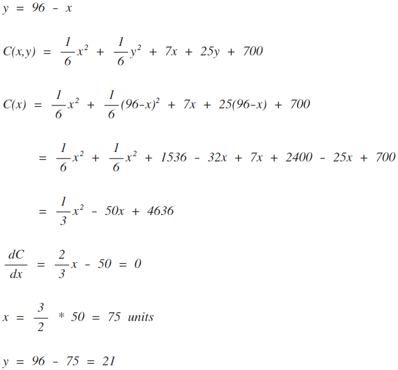

5. Evaluate the double integral on the given region.

Write your answer in exact form without decimals.

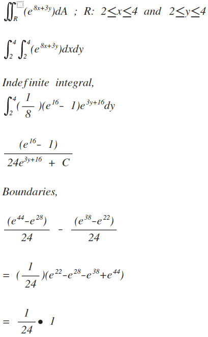